# Avaliação - I Workshop Programe_CE

O **I Workshop do Programe_CE e Aula Magna da Especialização em Pensamento Computacional** foi realizado no dia 02 de fevereiro de 2022, com objetivo de promover o diálogo a respeito do desenvolvimento do projeto Programe_CE nas Escolas de Ensino Médio em Tempo Integral e realizar a abertura oficial do curso de Especialização em Pensamento Computacional da Universidade Federal do Ceará (UFC) para professores da rede estadual.

Ao final do Workshop, foi solicitado aos participantes (Diretores, Coordenadores, Professores, Tutores e Formadores) que respondessem um questionário avaliando seis aspectos do programa. As respostas seguiam uma escala de 1 a 5, em que 1 representava a avaliação mais baixa do aspecto pedido e 5 a avaliação mais alta. Também foi disponibilizado um campo para comentários livres. Abaixo disponibilizamos os resultados agregados e segmentados por tipo de função do respondente.

Ao todo, tivemos **54** respondestes à avaliação.

# Respostas ao questionário de avaliação - Geral

## Avalie a adequação dos Materiais de Formação

| Avaliação | Respondentes | Percentual |
| --- | --- | --- |
| Ótimo | 30 | 55.6 |
| Bom | 17 | 31.5 |
| Neutro | 4 | 7.4 |
| Ruim | 3 | 5.6 |

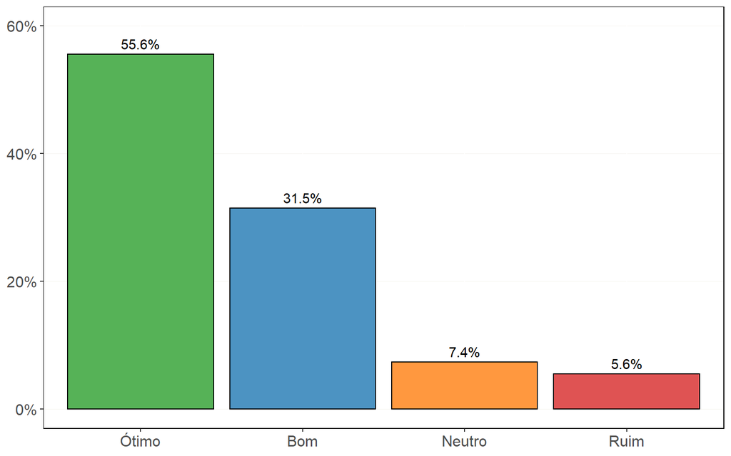

## Avalie a metodologia das aulas e das tutorias

| Avaliação | Respondentes | Percentual |
| --- | --- | --- |
| Ótimo | 24 | 44.4 |
| Bom | 23 | 42.6 |
| Neutro | 6 | 11.1 |
| Péssimo | 1 | 1.8 |

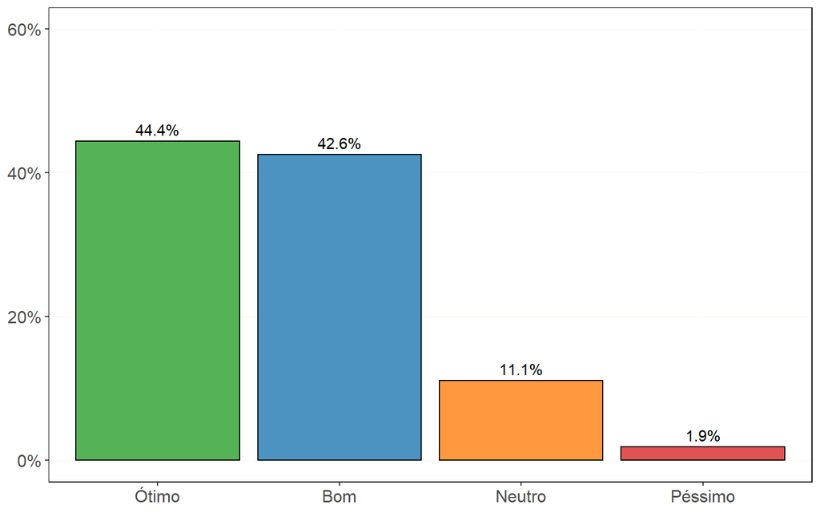

## Avalie a atuação do Tutor

| Avaliação | Respondentes | Percentual |
| --- | --- | --- |
| Ótimo | 26 | 48.1 |
| Bom | 23 | 42.6 |
| Neutro | 4 | 7.4 |
| Péssimo | 1 | 1.8 |

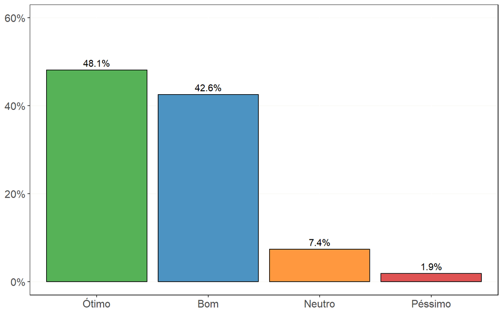

## Avalie a infraestrutura e o apoio logístico para as aulas do projeto

| Avaliação | Respondentes | Percentual |
| --- | --- | --- |
| Ótimo | 29 | 53.7 |
| Bom | 13 | 24.1 |
| Neutro | 9 | 16.7 |
| Péssimo | 2 | 3.7 |
| Ruim | 1 | 1.8 |

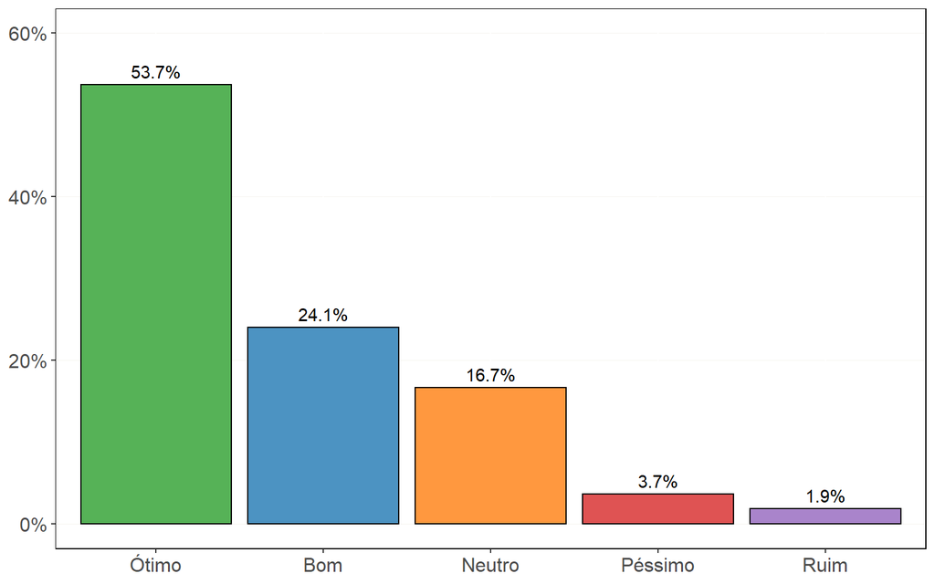

## Avalie o engajamento institucional (Secretaria / COETI / Núcleo Gestor / Núcleo Pedagógico)

| Avaliação | Respondentes | Percentual |
| --- | --- | --- |
| Ótimo | 29 | 53.7 |
| Bom | 20 | 37.0 |
| Neutro | 3 | 5.6 |
| Péssimo | 2 | 3.7 |

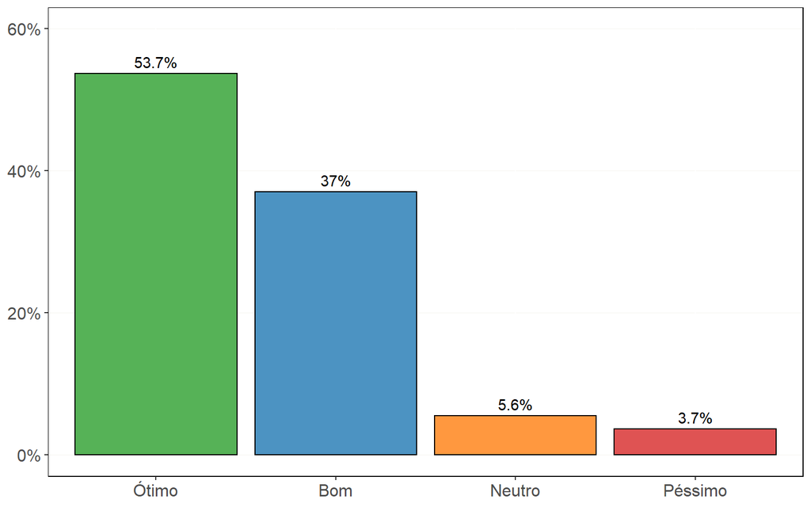

## Avalie o engajamento dos alunos

| Avaliação | Respondentes | Percentual |
| --- | --- | --- |
| Bom | 22 | 40.7 |
| Ótimo | 17 | 31.5 |
| Neutro | 12 | 22.2 |
| Ruim | 2 | 3.7 |
| Péssimo | 1 | 1.8 |

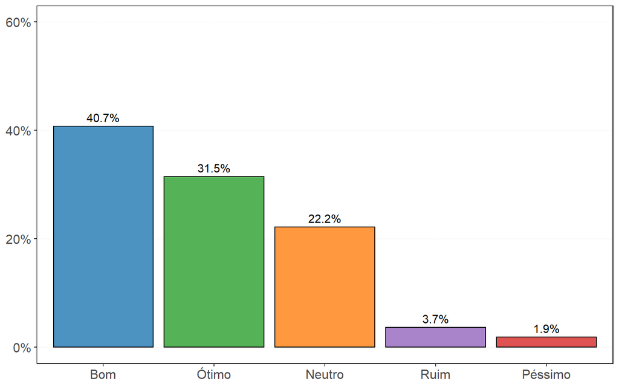

# DIRETORES - Respostas ao questionário de avaliação

Abaixo, as repostas de **28** classificados como Diretor/Coordenador/CEDEA/Superintendente/Professor.

## Avalie a adequação dos Materiais de Formação

| Avaliação | Respondentes | Percentual |
| --- | --- | --- |
| Ótimo | 17 | 60.7 |
| Bom | 8 | 28.6 |
| Neutro | 3 | 10.7 |

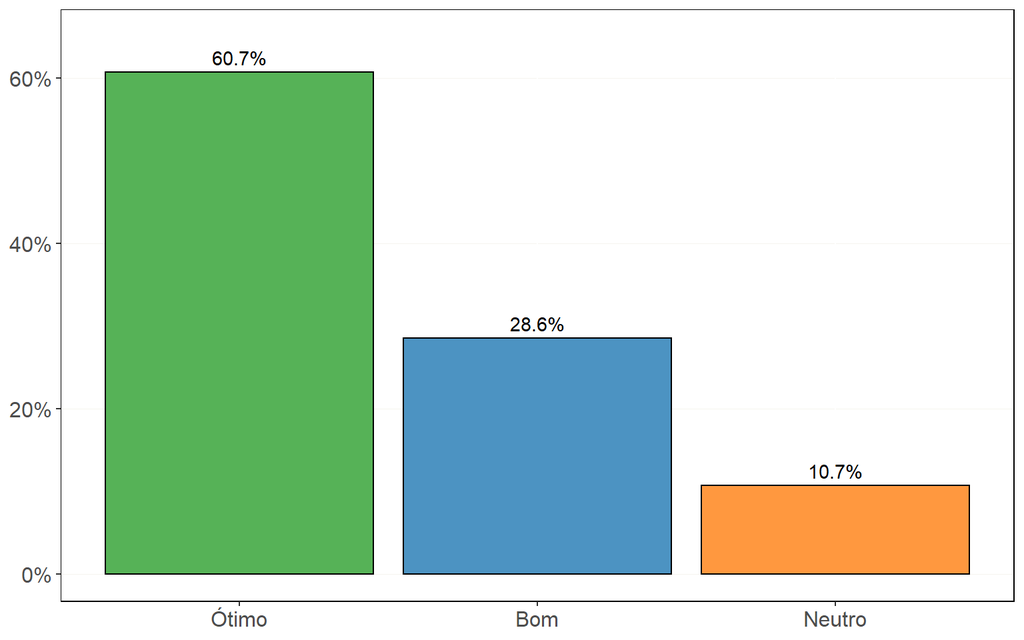

## Avalie a metodologia das aulas e das tutorias

| Avaliação | Respondentes | Percentual |
| --- | --- | --- |
| Ótimo | 12 | 42.86 |
| Bom | 11 | 39.29 |
| Neutro | 4 | 14.29 |
| Péssimo | 1 | 3.57 |

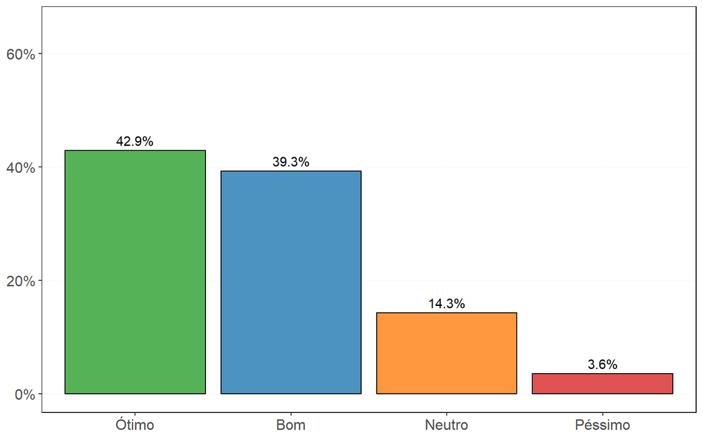

## Avalie a atuação do Tutor

| Avaliação | Respondentes | Percentual |
| --- | --- | --- |
| Bom | 13 | 46.43 |
| Ótimo | 12 | 42.86 |
| Neutro | 2 | 7.14 |
| Péssimo | 1 | 3.57 |

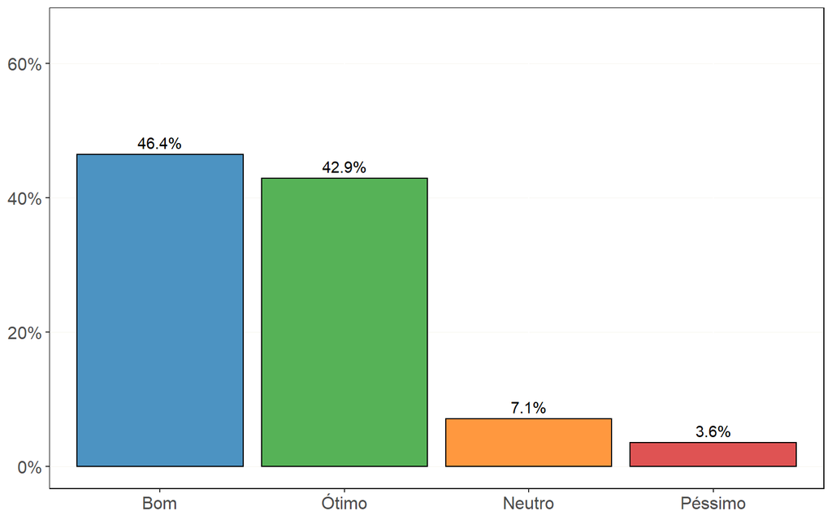

## Avalie a infraestrutura e o apoio logístico para as aulas do projeto

| Avaliação | Respondentes | Percentual |
| --- | --- | --- |
| Ótimo | 16 | 57.14 |
| Bom | 7 | 25.00 |
| Neutro | 3 | 10.71 |
| Péssimo | 1 | 3.57 |
| Ruim | 1 | 3.57 |

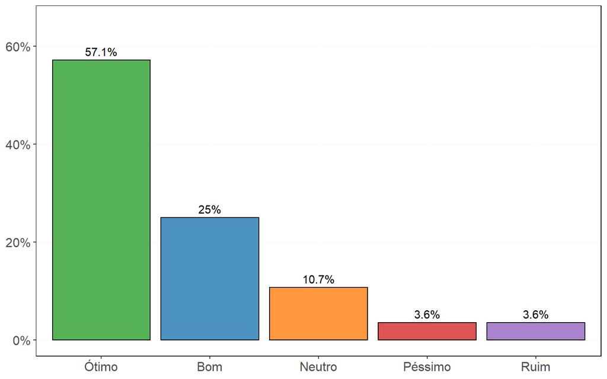

## Avalie o engajamento institucional (Secretaria / COETI / Núcleo Gestor / Núcleo Pedagógico)

| Avaliação | Respondentes | Percentual |
| --- | --- | --- |
| Ótimo | 17 | 60.71 |
| Bom | 10 | 35.71 |
| Péssimo | 1 | 3.57 |

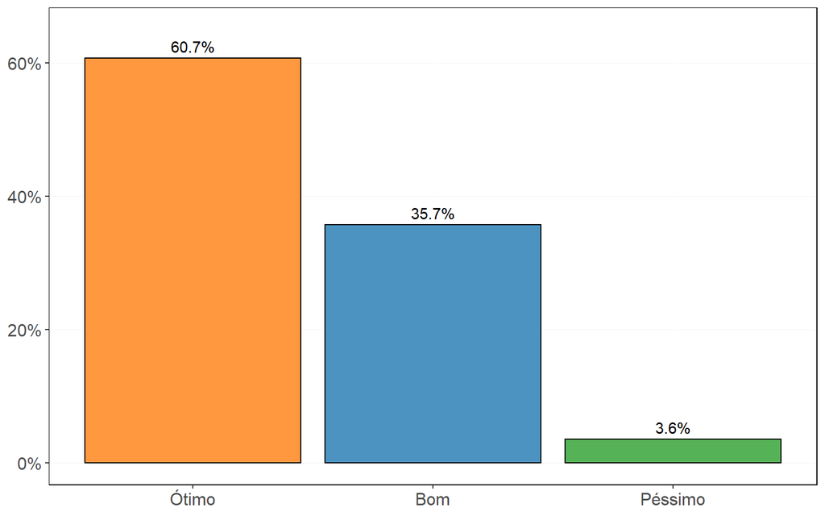

## Avalie o engajamento dos alunos

| Avaliação | Respondentes | Percentual |
| --- | --- | --- |
| Bom | 13 | 46.43 |
| Ótimo | 10 | 35.71 |
| Neutro | 3 | 10.71 |
| Péssimo | 1 | 3.57 |
| Ruim | 1 | 3.57 |

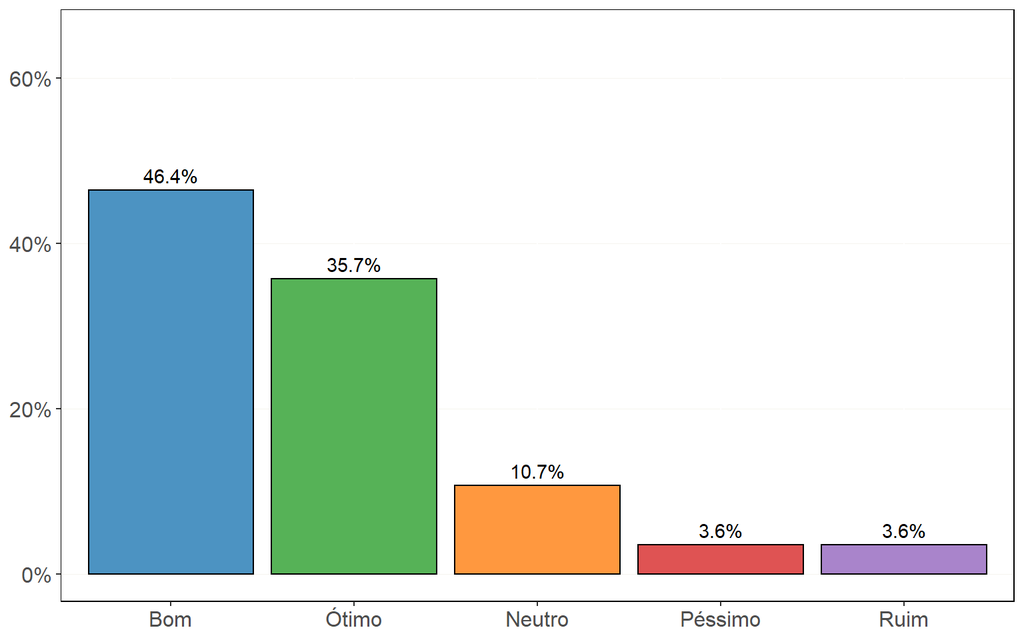

## Comentários dos Diretores

| Comentários |
| --- |
| AMPLIAÇÃO |
| O módulo 1, teve suas dificuldades por conta da pandemia. Acreditamos que o módulo 2, vai ser nota 10. |
| Momento de escuta e planejamento coletivo entre tutores e escola |
| É um projeto inovador e precisa ser ampliado. |
| Diversificar a metodologia para aulas mais ativas e menos expositivas. Reduzir o uso e número de slides para ações “mão na massa”. |
| Formação dos TR para a avaliação dos alunos |
| Parabéns pelo excelente programa! |
| Sugerimos que o tutor socialize com a escola o planejamento das aulas das turmas. |
| Acredito que esse ano as atividades vão fluir melhor. Quando as atividades tiveram início, as Escolas estavam iniciando o retorno presencial por conta da pandemia e essa conjuntura de certa forma pode… |
| melhoramento das estruturas da internet das escolas. |
| Conheço alguns materiais ainda não fiz a impressão devido não ter conhecimento se será utilizado na especialização. Nosso LEI está precisando de novos aparelhos (temos aqueles antigos, sucateados, …..… |
| Maior envolvimento da Seduc com as escolas. |
| Por novas turmas de programe_ce |
| O programa poderia abrir turmas novas , além da turma que irá sequenciar o mesmo. por exemplo: a turma do ano passado irá continuar o curso e ao mesmo tempo poderia abrir uma nova turma para iniciar o… |

# TUTORES - Respostas ao questionário de avaliação

Abaixo, as repostas de **14** Tutores.

## Avalie a adequação dos Materiais de Formação

| Avaliação | Respondentes | Percentual |
| --- | --- | --- |
| Ótimo | 7 | 50.00 |
| Bom | 5 | 35.71 |
| Neutro | 1 | 7.14 |
| Ruim | 1 | 7.14 |

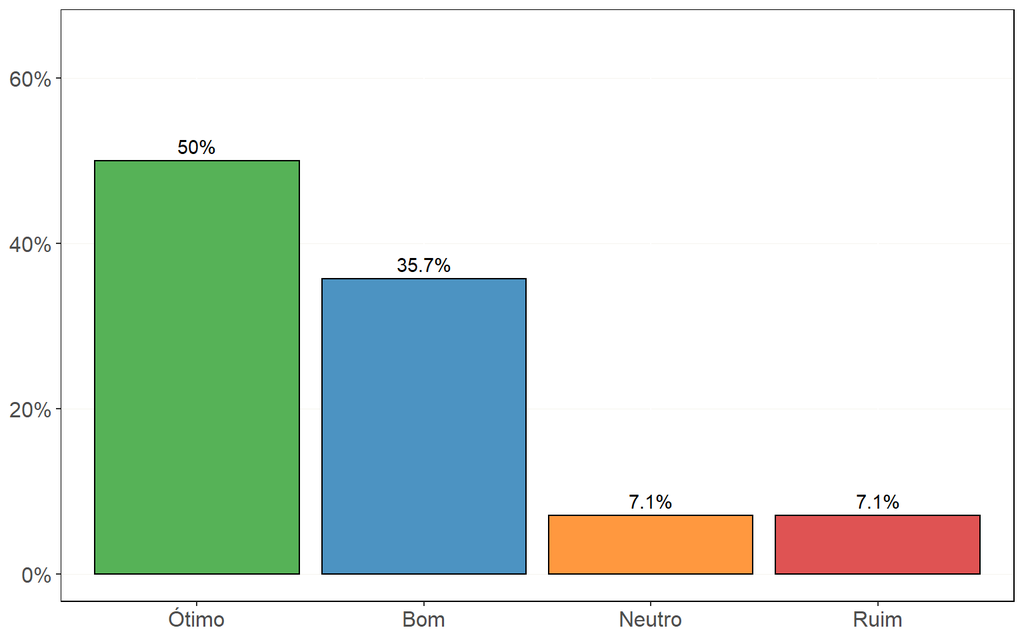

## Avalie a metodologia das aulas e das tutorias

| Avaliação | Respondentes | Percentual |
| --- | --- | --- |
| Bom | 7 | 50 |
| Ótimo | 7 | 50 |

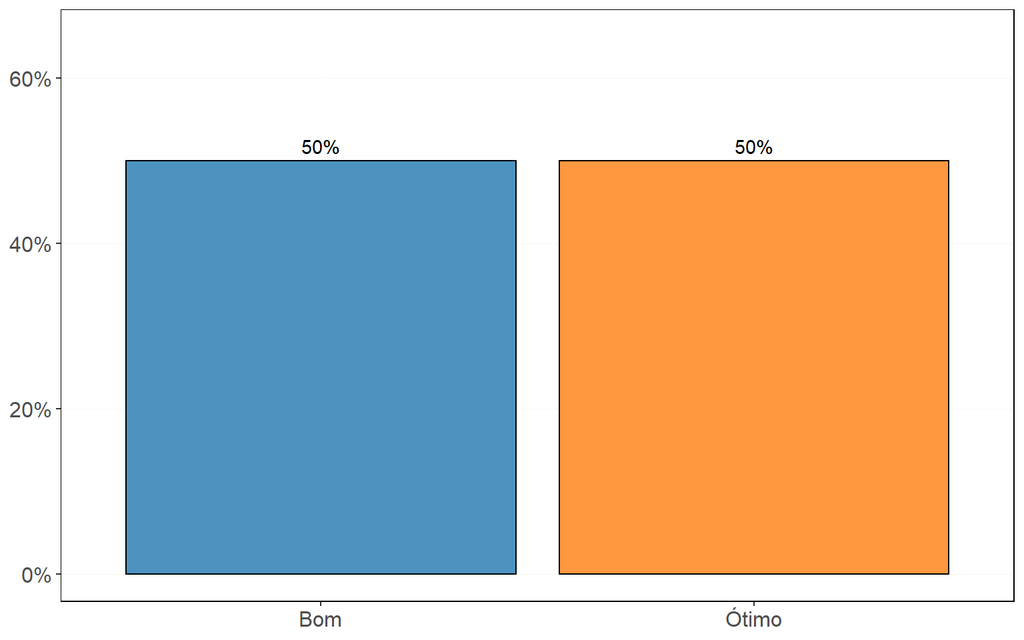

## Avalie a atuação do Tutor

| Avaliação | Respondentes | Percentual |
| --- | --- | --- |
| Ótimo | 8 | 57.1 |
| Bom | 6 | 42.9 |

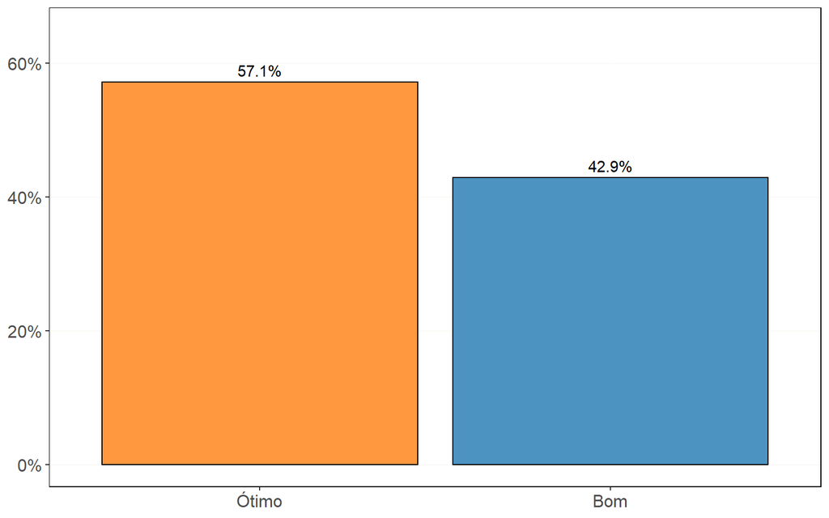

## Avalie a infraestrutura e o apoio logístico para as aulas do projeto

| Avaliação | Respondentes | Percentual |
| --- | --- | --- |
| Ótimo | 8 | 57.14 |
| Bom | 4 | 28.57 |
| Neutro | 1 | 7.14 |
| Péssimo | 1 | 7.14 |

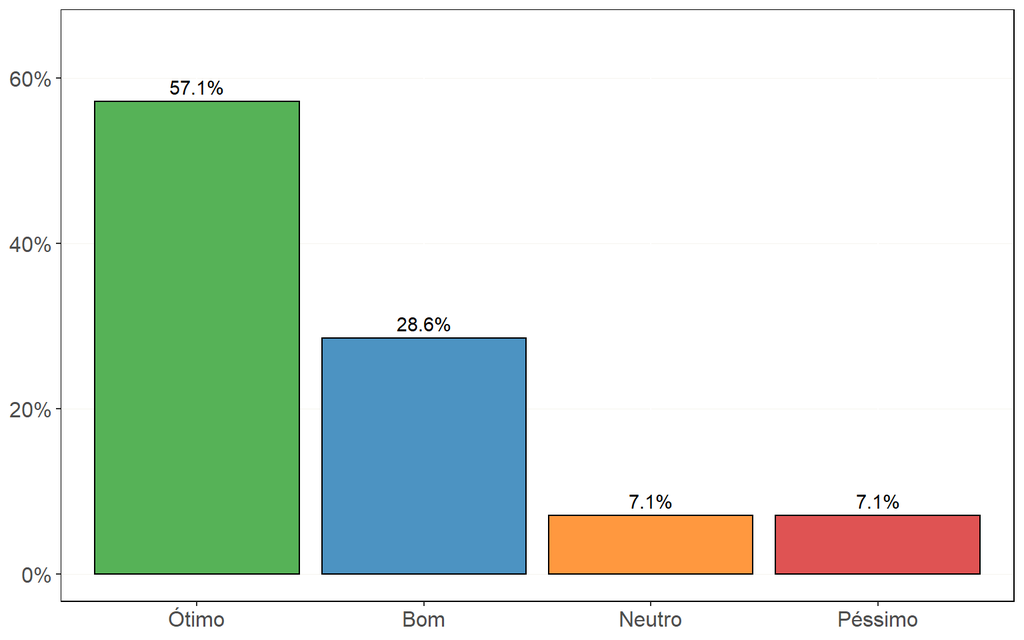

## Avalie o engajamento institucional (Secretaria / COETI / Núcleo Gestor / Núcleo Pedagógico)

| Avaliação | Respondentes | Percentual |
| --- | --- | --- |
| Bom | 6 | 42.86 |
| Ótimo | 5 | 35.71 |
| Neutro | 2 | 14.29 |
| Péssimo | 1 | 7.14 |

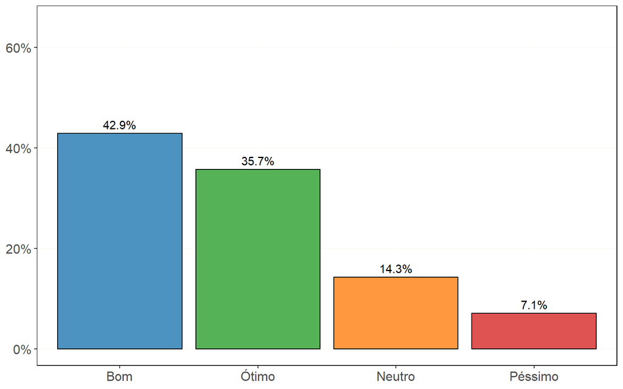

## Avalie o engajamento dos alunos

| Avaliação | Respondentes | Percentual |
| --- | --- | --- |
| Bom | 7 | 50.00 |
| Neutro | 5 | 35.71 |
| Ótimo | 1 | 7.14 |
| Ruim | 1 | 7.14 |

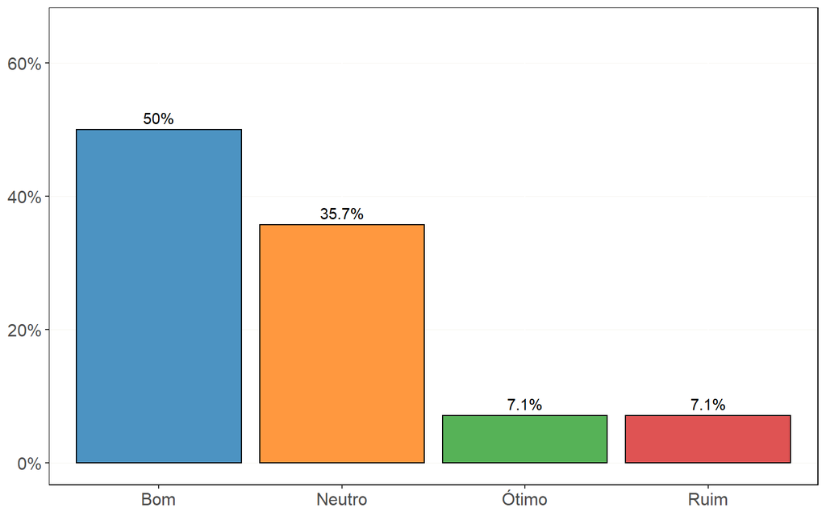

## Comentários dos Tutores

| Comentários |
| --- |
| O nível dos conteúdos deve estar mais próximo da realidade dos alunos. |
| Programa super interessante e inovador, contudo o primeiro material poderia ter sido mais breve e direto, um cronograma mais enxuto, mas que falaram que já ouve adequações para o próximo modulo. Para … |
| mais políticas públicas para o melhoramento das redes de internet nas escolas |
| Fiz uma pesquisa dessas com minhas turmas anteriormente e o ponto que eles mais citaram foi ter muita teoria e pouco tempo para práticas durante as aulas. Quero destacar um ponto positivo também, que … |
| Algo importante é a disponibilização livro logo de inicio das aulas, como o material ainda está sendo elaborado, é algo para o futuro. Bem como o esclarecimento sobre o programa para os alunos logo de… |

# FORMADORES - Respostas ao questionário de avaliação

Abaixo, as repostas de **12** Formadores.

## Avalie a adequação dos Materiais de Formação

| Avaliação | Respondentes | Percentual |
| --- | --- | --- |
| Ótimo | 6 | 50.0 |
| Bom | 4 | 33.3 |
| Ruim | 2 | 16.7 |

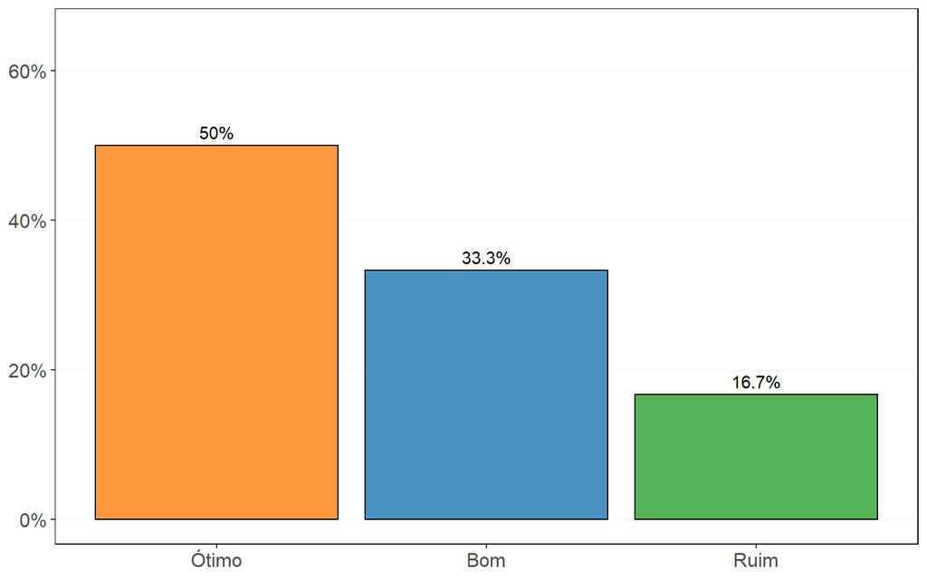

## Avalie a metodologia das aulas e das tutorias

| Avaliação | Respondentes | Percentual |
| --- | --- | --- |
| Bom | 5 | 41.7 |
| Ótimo | 5 | 41.7 |
| Neutro | 2 | 16.7 |

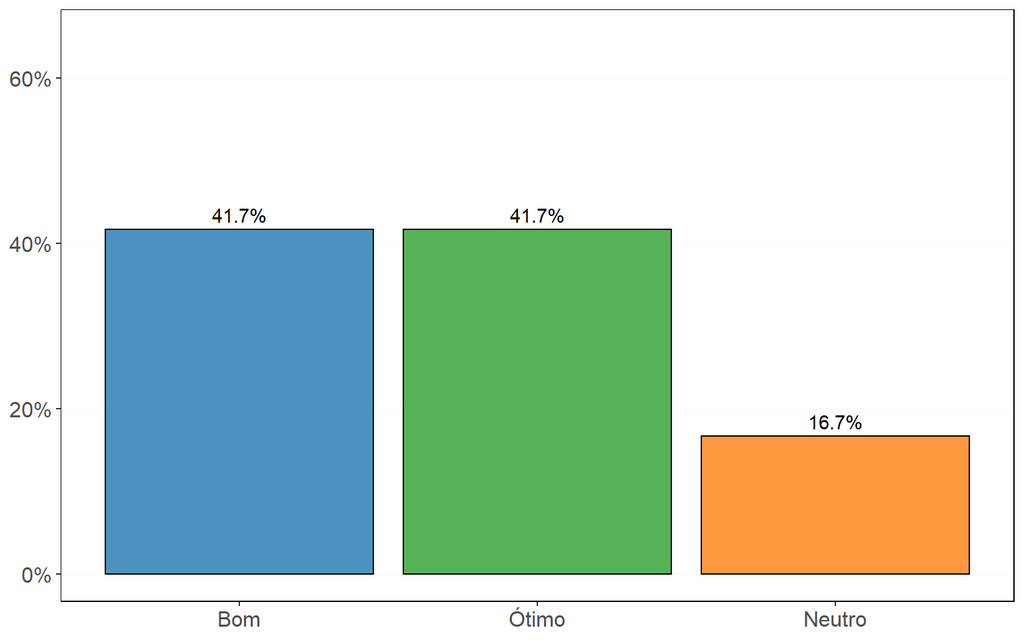

## Avalie a atuação do Tutor

| Avaliação | Respondentes | Percentual |
| --- | --- | --- |
| Ótimo | 6 | 50.0 |
| Bom | 4 | 33.3 |
| Neutro | 2 | 16.7 |

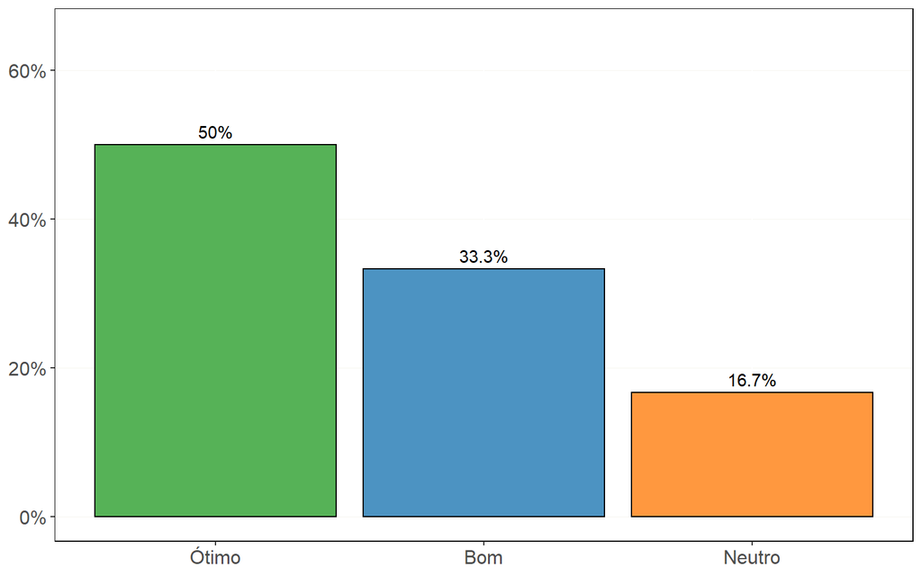

## Avalie a infraestrutura e o apoio logístico para as aulas do projeto

| Avaliação | Respondentes | Percentual |
| --- | --- | --- |
| Neutro | 5 | 41.7 |
| Ótimo | 5 | 41.7 |
| Bom | 2 | 16.7 |

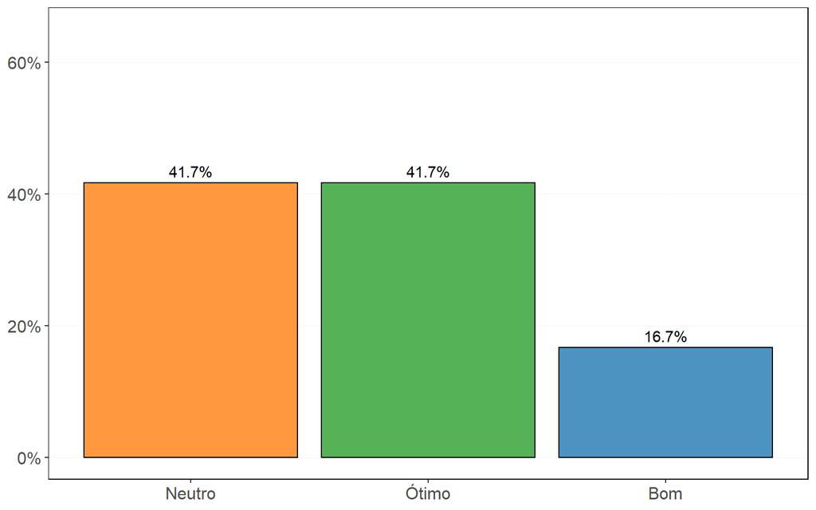

## Avalie o engajamento institucional (Secretaria / COETI / Núcleo Gestor / Núcleo Pedagógico)

| Avaliação | Respondentes | Percentual |
| --- | --- | --- |
| Ótimo | 7 | 58.33 |
| Bom | 4 | 33.33 |
| Neutro | 1 | 8.33 |

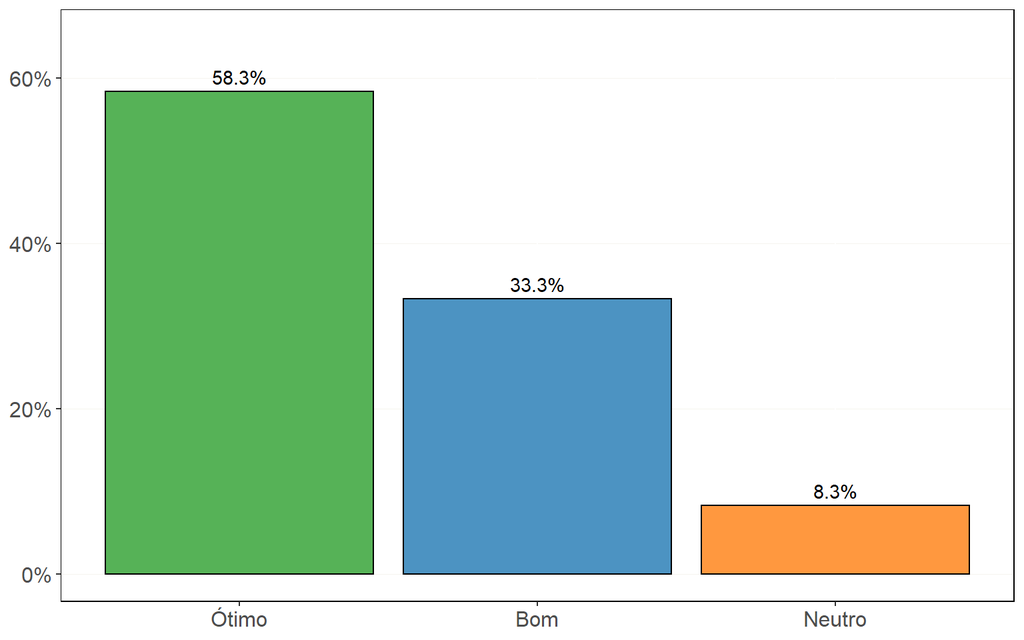

## Avalie o engajamento dos alunos

| Avaliação | Respondentes | Percentual |
| --- | --- | --- |
| Ótimo | 6 | 50.0 |
| Neutro | 4 | 33.3 |
| Bom | 2 | 16.7 |

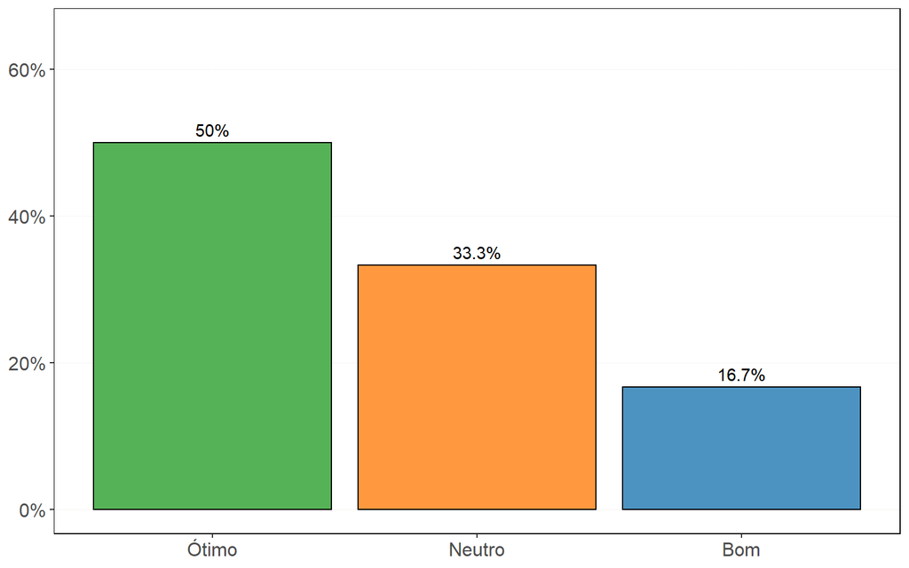

## Comentários dos Formadores

| Comentários |
| --- |
| Importante observar a infraestrutura em relação a equipamentos, tais como, projetores e disponibilização de lab exclusivos para o Programe_Ce (deixar laboratórios abertos fora do horário de aula para … |
| . |
| Fiz minha inscrição, mas não obtive retorno. Uma dúvida: essa pós é somente para professores efetivos? |